# AssignmentMetaanalysis

hanwenmiao 436819

2024-05-27

##Load the packages

##Import the data.

```r
setwd("C:/Users/lulut/Desktop/forked/11. Metaanalysis")
data <- read_excel("data/metaanalysis_data.xlsx")
head(data)
```

```
## # A tibble: 6 × 28
##   Study            `Female authors` `Male authors` `Age (months)` N_boys N_girls
##   <chr>                       <dbl>          <dbl>          <dbl>  <dbl>   <dbl>
## 1 Alexander & Sae…                2              0           19.5     47      47
## 2 Arthur (2014)                   1              0           19       22      18
## 3 Berenbaum & Hin…                2              0           65.8     18      18
## 4 Berenbaum & Sny…                2              0           93.1     19      19
## 5 Doering et al (…                1              3           87       15      15
## 6 Idle et al. (19…                2              1           46       10      10
## # ℹ 22 more variables: Mean_boys_play_male <dbl>, SD_boys_play_male <dbl>,
## #   Mean_girls_play_male <dbl>, SD_girls_play_male <dbl>,
## #   Mean_boys_play_female <dbl>, SD_boys_play_female <dbl>,
## #   Mean_girls_play_female <dbl>, SD_girls_play_female <dbl>,
## #   `Neutral toys` <dbl>, Year <dbl>, `Parent present` <dbl>, Setting <dbl>,
## #   Country <dbl>, `Case definition adequate` <chr>,
## #   `Representativeness of cases` <chr>, `Selection of controls` <chr>, …
```

##Set two groups of variables. The first group - control group.(Mean_boys_play_male and Mean_girls_play_female). Then calculate the effect size and combine the effect.

```r
m.control <- metacont(
  n.e = N_boys,
  mean.e = Mean_boys_play_male,
  sd.e = SD_boys_play_male,
  n.c = N_girls,
  mean.c = Mean_girls_play_female,
  sd.c = SD_girls_play_female,
  data = data,
  studlab = Study,
  fixed = TRUE,
  random = TRUE
)
summary(m.control)
```

```
##                                            MD                95%-CI %W(common)
## Alexander & Saenz (2012)             -99.8400 [-177.3014; -22.3786]        0.9
## Arthur (2014)                        -96.0000 [-146.4719; -45.5281]        2.0
## Berenbaum & Hines (1992)              77.3200 [ -91.6464; 246.2864]        0.2
## Berenbaum & Snyder (1995)            218.7900 [  93.2900; 344.2900]        0.3
## Doering et al (1989)                 114.9000 [  49.7076; 180.0924]        1.2
## Idle et al. (1993)                   252.7000 [ 137.3637; 368.0363]        0.4
## Lamminmäki & Hines (2012)            -33.8900 [ -76.4384;   8.6584]        2.9
## Li & Wong (2016)                      31.4200 [ -24.8298;  87.6698]        1.6
## Pasterski et al. (2005)              129.6000 [  12.6271; 246.5729]        0.4
## Pasterski et al. (2005)               -3.6000 [ -90.6936;  83.4936]        0.7
## Pasterski et al. (2005)               32.4000 [ -35.5834; 100.3834]        1.1
## Schau et al. (1980)                  190.1200 [  89.0287; 291.2113]        0.5
## Servin et al. (1999)                 -92.7900 [-157.0827; -28.4973]        1.3
## Servin et al. (1999)                  64.0500 [ -28.7203; 156.8203]        0.6
## Servin et al. (1999)                 104.9700 [  18.2831; 191.6569]        0.7
## Todd et al. (2016)                   -10.4000 [ -31.5115;  10.7115]       11.7
## Todd et al. (2016)                   -10.4000 [ -29.5602;   8.7602]       14.2
## Todd et al. (2016)                    16.1000 [  -4.8747;  37.0747]       11.8
## van de Beek (2009)                   -19.8400 [ -60.2180;  20.5380]        3.2
## Wilansky-Traynor & Lobel (2008)       10.0300 [ -32.9703;  53.0303]        2.8
## Wilansky-Traynor & Lobel (2008)        5.8600 [ -36.2014;  47.9214]        2.9
## Zosuls et al. (2009)                 -18.0000 [ -63.9234;  27.9234]        2.5
## Zosuls et al. (2009)                 -72.0000 [-136.7085;  -7.2915]        1.2
## Zosuls et al. (2009)                 -54.0000 [-100.7844;  -7.2156]        2.4
## Zosuls et al. (2009)                 -54.0000 [-103.3809;  -4.6191]        2.1
## Zosuls, Ruble & Tamis-LeMonda (2014)   2.7000 [ -14.4967;  19.8967]       17.6
## Zosuls, Ruble & Tamis-LeMonda (2014)  -8.1000 [ -28.3275;  12.1275]       12.7
##                                      %W(random)
## Alexander & Saenz (2012)                    3.5
## Arthur (2014)                               4.0
## Berenbaum & Hines (1992)                    1.8
## Berenbaum & Snyder (1995)                   2.5
## Doering et al (1989)                        3.7
## Idle et al. (1993)                          2.7
## Lamminmäki & Hines (2012)                   4.2
## Li & Wong (2016)                            3.9
## Pasterski et al. (2005)                     2.7
## Pasterski et al. (2005)                     3.3
## Pasterski et al. (2005)                     3.7
```

[output cut: 21 more lines]

```
## Common effect model  -3.5717 [-10.7863;  3.6428] -0.97  0.3319
## Random effects model 14.3050 [-15.5035; 44.1136]  0.94  0.3469
##
## Quantifying heterogeneity:
##  tau^2 = 5085.6367 [3081.8461; 13848.4863]; tau = 71.3136 [55.5144; 117.6796]
##  I^2 = 78.7% [69.5%; 85.1%]; H = 2.16 [1.81; 2.59]
##
## Test of heterogeneity:
##       Q d.f.  p-value
##  121.78   26 < 0.0001
##
## Details on meta-analytical method:
## - Inverse variance method
## - Restricted maximum-likelihood estimator for tau^2
## - Q-Profile method for confidence interval of tau^2 and tau
```

[figure not shown]

```r
##Draw a forest plot
m.control %>% forest(sortvar=TE)
```

```r
regression1 <- metareg(m.control, formula = `Parental opinion` + `Representativeness of cases`)
summary(regression1)
```

```
##
## Mixed-Effects Model (k = 27; tau^2 estimator: REML)
##
##    logLik   deviance        AIC        BIC       AICc
## -140.2244   280.4487   288.4487   293.1610   290.5540
##
## tau^2 (estimated amount of residual heterogeneity):     4905.3662 (SE = 1731.3711)
## tau (square root of estimated tau^2 value):             70.0383
## I^2 (residual heterogeneity / unaccounted variability): 91.68%
## H^2 (unaccounted variability / sampling variability):   12.02
## R^2 (amount of heterogeneity accounted for):            3.54%
##
## Test for Residual Heterogeneity:
## QE(df = 24) = 115.1274, p-val < .0001
##
## Test of Moderators (coefficients 2:3):
## QM(df = 2) = 4.3555, p-val = 0.1133
##
## Model Results:
##
##                                 estimate       se     zval    pval      ci.lb
## intrcpt                          50.2872  24.0145   2.0940  0.0363     3.2196
## `Parental opinion`X             -63.2263  30.2979  -2.0868  0.0369  -122.6091
## `Representativeness of cases`X  -11.1658  38.1802  -0.2925  0.7699   -85.9976
##                                   ci.ub
## intrcpt                         97.3548  *
## `Parental opinion`X             -3.8436  *
## `Representativeness of cases`X  63.6660
##
## ---
## Signif. codes:  0 '***' 0.001 '**' 0.01 '*' 0.05 '.' 0.1 ' ' 1
```

##Based on the QM statistic results, these two variables are not significant. However, to confirm the significance of each variable,Parental opinion has an effect on the results at the 5% significance level. ##Use metareg to check if author gender affects results

```r
author_gender_reg1 <- metareg(m.control, formula = `Female authors` + `Male authors`)
summary(author_gender_reg1)
```

```
##
## Mixed-Effects Model (k = 27; tau^2 estimator: REML)
##
##    logLik   deviance        AIC        BIC       AICc
## -141.1164   282.2327   290.2327   294.9450   292.3380
##
## tau^2 (estimated amount of residual heterogeneity):     5046.4353 (SE = 1768.2411)
## tau (square root of estimated tau^2 value):             71.0383
## I^2 (residual heterogeneity / unaccounted variability): 92.35%
## H^2 (unaccounted variability / sampling variability):   13.08
## R^2 (amount of heterogeneity accounted for):            0.77%
##
## Test for Residual Heterogeneity:
## QE(df = 24) = 115.3810, p-val < .0001
##
## Test of Moderators (coefficients 2:3):
## QM(df = 2) = 2.4950, p-val = 0.2872
##
## Model Results:
##
##                   estimate       se     zval    pval     ci.lb     ci.ub
## intrcpt            70.3000  45.6474   1.5401  0.1235  -19.1672  159.7672
## `Female authors`  -25.0774  16.4546  -1.5240  0.1275  -57.3278    7.1730
## `Male authors`     12.3914  14.8996   0.8317  0.4056  -16.8113   41.5941
##
## ---
## Signif. codes:  0 '***' 0.001 '**' 0.01 '*' 0.05 '.' 0.1 ' ' 1
```

##According to the result. Female authors and Male authors do not have a significant effect on the model results at the 5% significance level. ##Create a ‘contour-enhanced’ funnel plot.

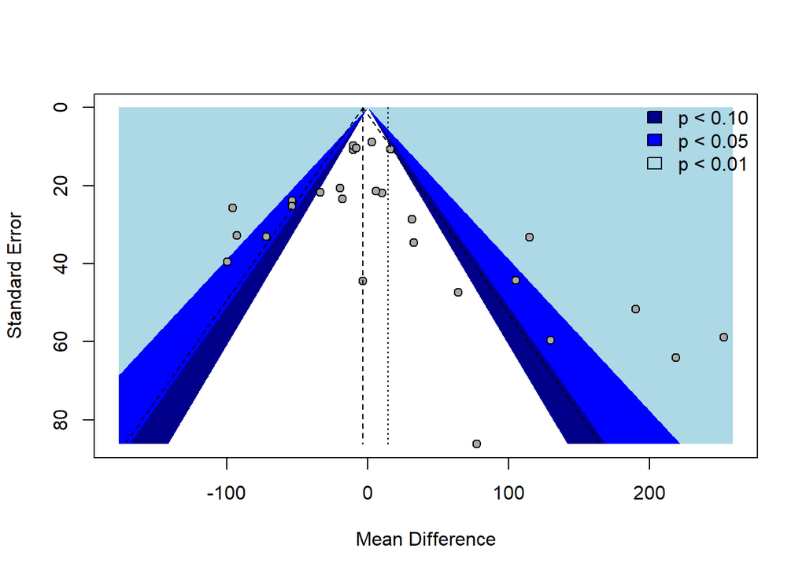

```r
contour_levels <- c(0.90, 0.95, 0.99)
contour_colors <- c("darkblue", "blue", "lightblue")
funnel(m.control, contour = contour_levels, col.contour = contour_colors)
legend("topright", c("p < 0.10", "p < 0.05", "p < 0.01"), bty = "n", fill = contour_colors)
```

##The second group of variables:(Mean_boys_play_female and Mean_girls_play_male) And check the effect size.

```r
m.control2 <- metacont(
  n.e = N_boys,
  mean.e = Mean_boys_play_female,
  sd.e = SD_boys_play_female,
  n.c = N_girls,
  mean.c = Mean_girls_play_male,
  sd.c = SD_girls_play_male,
  data = data,
  studlab = data$Study,
  fixed = TRUE,
  random = TRUE
)
summary(m.control2)
```

```
##                                             MD                95%-CI %W(common)
## Alexander & Saenz (2012)              128.6400 [  61.4642; 195.8158]        0.4
## Arthur (2014)                          72.0000 [  34.8071; 109.1929]        1.2
## Berenbaum & Hines (1992)             -101.6300 [-200.2016;  -3.0584]        0.2
## Berenbaum & Snyder (1995)            -176.0600 [-262.2302; -89.8898]        0.2
## Doering et al (1989)                  -91.2000 [-143.6058; -38.7942]        0.6
## Idle et al. (1993)                   -134.6000 [-238.4112; -30.7888]        0.1
## Lamminmäki & Hines (2012)              47.1100 [  11.4948;  82.7252]        1.3
## Li & Wong (2016)                      -16.4200 [ -50.1677;  17.3277]        1.4
## Pasterski et al. (2005)                14.4000 [  -7.5376;  36.3376]        3.3
## Pasterski et al. (2005)                 0.0000 [ -54.9634;  54.9634]        0.5
## Pasterski et al. (2005)               -25.2000 [ -71.5804;  21.1804]        0.7
## Schau et al. (1980)                   -39.4000 [ -96.5390;  17.7390]        0.5
## Servin et al. (1999)                  106.3400 [  48.9458; 163.7342]        0.5
## Servin et al. (1999)                  -66.5600 [-118.8021; -14.3179]        0.6
## Servin et al. (1999)                 -126.6700 [-186.1042; -67.2358]        0.5
## Todd et al. (2016)                      1.6000 [  -6.1698;   9.3698]       26.4
## Todd et al. (2016)                     -6.2000 [ -15.0414;   2.6414]       20.4
## Todd et al. (2016)                      0.4000 [ -11.8133;  12.6133]       10.7
## van de Beek (2009)                     39.5000 [   2.3021;  76.6979]        1.2
## Wilansky-Traynor & Lobel (2008)       -17.0200 [ -54.7445;  20.7045]        1.1
## Wilansky-Traynor & Lobel (2008)       -20.4900 [ -57.7952;  16.8152]        1.1
## Zosuls et al. (2009)                   48.0000 [   7.0748;  88.9252]        1.0
## Zosuls et al. (2009)                   24.0000 [   0.0756;  47.9244]        2.8
## Zosuls et al. (2009)                   54.0000 [  16.2993;  91.7007]        1.1
## Zosuls et al. (2009)                   42.0000 [   3.1947;  80.8053]        1.1
## Zosuls, Ruble & Tamis-LeMonda (2014)   -2.7000 [ -13.4498;   8.0498]       13.8
## Zosuls, Ruble & Tamis-LeMonda (2014)  -10.8000 [ -25.1840;   3.5840]        7.7
##                                      %W(random)
## Alexander & Saenz (2012)                    3.2
## Arthur (2014)                               3.9
## Berenbaum & Hines (1992)                    2.4
## Berenbaum & Snyder (1995)                   2.7
## Doering et al (1989)                        3.5
## Idle et al. (1993)                          2.3
## Lamminmäki & Hines (2012)                   3.9
## Li & Wong (2016)                            4.0
## Pasterski et al. (2005)                     4.2
## Pasterski et al. (2005)                     3.5
## Pasterski et al. (2005)                     3.7
```

[output cut: 21 more lines]

```
## Common effect model   0.2264 [ -3.7627;  4.2155]  0.11  0.9114
## Random effects model -4.2623 [-27.3012; 18.7765] -0.36  0.7169
##
## Quantifying heterogeneity:
##  tau^2 = 3181.2921 [1976.1324; 8347.9632]; tau = 56.4029 [44.4537; 91.3672]
##  I^2 = 82.4% [75.4%; 87.5%]; H = 2.39 [2.01; 2.83]
##
## Test of heterogeneity:
##       Q d.f.  p-value
##  148.07   26 < 0.0001
##
## Details on meta-analytical method:
## - Inverse variance method
## - Restricted maximum-likelihood estimator for tau^2
## - Q-Profile method for confidence interval of tau^2 and tau
```

[figure not shown]

```r
##Draw a forest plot
m.control2 %>% forest(sortvar=TE)
```

```r
## Use metareg to check if methods and quality affect results. Repeat the previous steps.
regression2 <- metareg(m.control2, formula = `Parental opinion` + `Representativeness of cases`)
summary(regression2)
```

```
##
## Mixed-Effects Model (k = 27; tau^2 estimator: REML)
##
##    logLik   deviance        AIC        BIC       AICc
## -134.7940   269.5879   277.5879   282.3002   279.6932
##
## tau^2 (estimated amount of residual heterogeneity):     3317.7195 (SE = 1111.2529)
## tau (square root of estimated tau^2 value):             57.5996
## I^2 (residual heterogeneity / unaccounted variability): 95.85%
## H^2 (unaccounted variability / sampling variability):   24.11
## R^2 (amount of heterogeneity accounted for):            0.00%
##
## Test for Residual Heterogeneity:
## QE(df = 24) = 137.1299, p-val < .0001
##
## Test of Moderators (coefficients 2:3):
## QM(df = 2) = 2.3564, p-val = 0.3078
##
## Model Results:
##
##                                 estimate       se     zval    pval     ci.lb
## intrcpt                         -20.6769  18.7962  -1.1001  0.2713  -57.5166
## `Parental opinion`X              34.9459  24.1159   1.4491  0.1473  -12.3205
## `Representativeness of cases`X  -10.5581  30.6253  -0.3447  0.7303  -70.5826
##                                   ci.ub
## intrcpt                         16.1629
## `Parental opinion`X             82.2123
## `Representativeness of cases`X  49.4665
##
## ---
## Signif. codes:  0 '***' 0.001 '**' 0.01 '*' 0.05 '.' 0.1 ' ' 1
```

##Parental opinion is not significant .

```r
author_gender_reg2 <- metareg(m.control2, formula = `Female authors` + `Male authors`)
summary(author_gender_reg2)
```

```
##
## Mixed-Effects Model (k = 27; tau^2 estimator: REML)
##
##    logLik   deviance        AIC        BIC       AICc
## -134.6107   269.2214   277.2214   281.9336   279.3266
##
## tau^2 (estimated amount of residual heterogeneity):     3139.6456 (SE = 1056.3502)
## tau (square root of estimated tau^2 value):             56.0325
## I^2 (residual heterogeneity / unaccounted variability): 95.77%
## H^2 (unaccounted variability / sampling variability):   23.65
## R^2 (amount of heterogeneity accounted for):            1.31%
##
## Test for Residual Heterogeneity:
## QE(df = 24) = 133.1763, p-val < .0001
##
## Test of Moderators (coefficients 2:3):
## QM(df = 2) = 2.8010, p-val = 0.2465
##
## Model Results:
##
##                   estimate       se     zval    pval      ci.lb    ci.ub
## intrcpt           -60.6575  35.7662  -1.6959  0.0899  -130.7579   9.4429  .
## `Female authors`   20.8783  12.9213   1.6158  0.1061    -4.4469  46.2035
## `Male authors`     -0.6328  11.2472  -0.0563  0.9551   -22.6769  21.4113
##
## ---
## Signif. codes:  0 '***' 0.001 '**' 0.01 '*' 0.05 '.' 0.1 ' ' 1
```

##We can see Authors’ genders do not affect results.

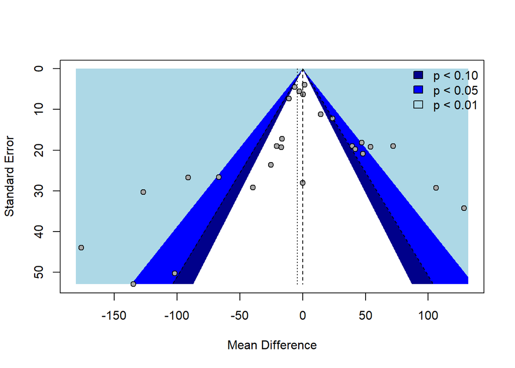

```r
funnel(m.control2, contour = contour_levels, col.contour = contour_colors)
legend("topright", c("p < 0.10", "p < 0.05", "p < 0.01"), bty = "n", fill = contour_colors)
```